# STA206 Fall 2022: Take Home Quiz

Sirapat Watakajaturaphon

**Instructions**:

- In this quiz, you will be asked to perform some tasks in R
- You should submit a .html (preferred format) or .docx file.
- You should only include the output that is directly related to answering the questions. A flood of unprocessed raw output from R may result in penalties.

In *Quiz_data.Rdata* you will find a data set called *data* with three variables: *Y* and *X1, X2*. For the following, **you should use the original data and no standardization should be applied**.

- **(a). Load the data into the R workspace. How many observations are there in this data?**

```r
load('Quiz_data.Rdata')
n = nrow(data)
n
```

```
## [1] 100
```

There are $n=100$ observations in this data.

- **(b). What is the type of each variable? For each variable, draw one plot to depict its distribution. Arrange these plots into one multiple paneled graph.**

```r
sapply(data, class) # type of each variable
```

```
##         Y        X1        X2
## "numeric" "numeric" "numeric"
```

All three variables are numeric. Then for each variable, draw a histogram to depict its distribution.

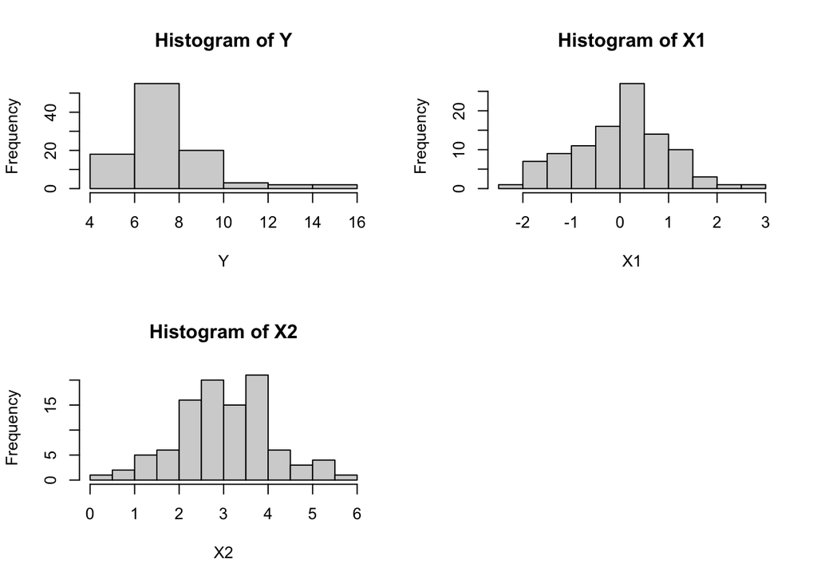

```r
par(mfrow=c(2,2))
for(i in 1:3) {
hist(data[,i], main=paste("Histogram of", names(data)[i]), xlab=paste(names(data)[i]))}
```

- **(c). Draw the scatter plot matrix and obtain the correlation matrix for these three variables. Briefly describe how *Y* appears to be related to *X1* and *X2*.**

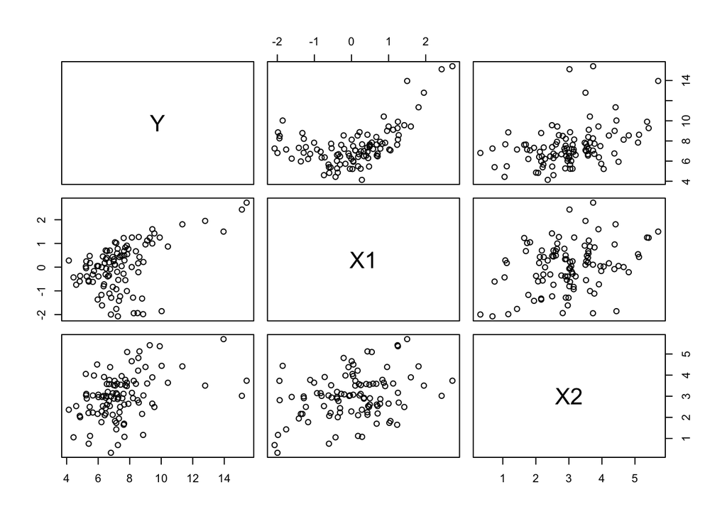

```r
par(mfrow=c(1,1))
pairs(data) # scatter plot matrix
```

```r
cor(data)   # correlation matrix
```

```
##            Y        X1        X2
## Y  1.0000000 0.4872571 0.3987890
## X1 0.4872571 1.0000000 0.3236289
## X2 0.3987890 0.3236289 1.0000000
```

- **(d). Fit a first-order model with *Y* as the response variable and *X1, X2* as the predictors (referred to as Model 1). How many regression coefficients are there in Model 1?**

```r
model1 = lm(Y ~ X1 + X2, data=data)
```

Model 1:
$$Y_i=\beta_0+\beta_1X_{i1}+\beta_2X_{i2}+\varepsilon_i,\quad
i=1,...,n=100.$$

There are 3 regression coefficients ($\beta_0,\beta_1,\beta_2$) in Model 1.

- **(e). Conduct model diagnostics for Model 1 and comment on how well model assumptions hold.**

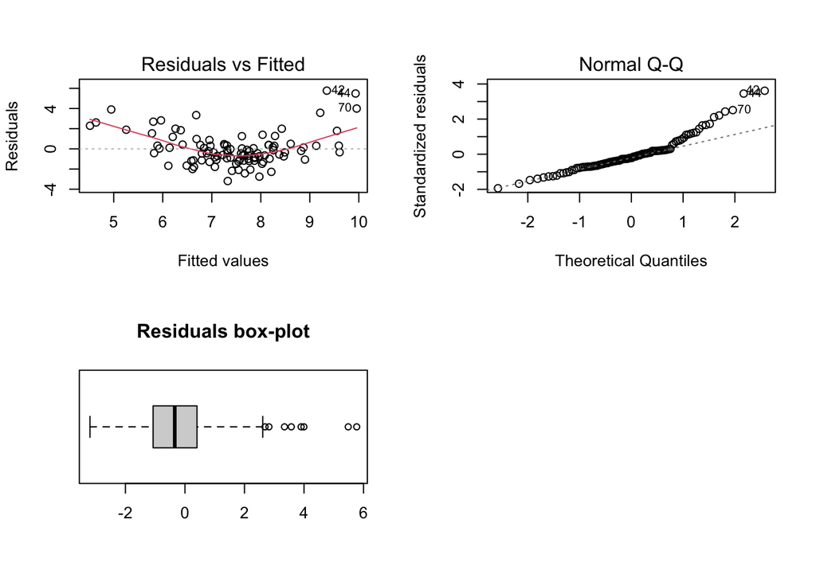

```r
par(mfrow=c(2,2))
plot(model1, which=1)
plot(model1, which=2)
boxplot(residuals(model1), horizontal=T, main='Residuals box-plot')
```

The model assumptions do not hold well:

- The residuals vs fitted plot. We can see a clear nonlinear pattern (so, linearity may be violated). The points spread fairly equally along the X-axis (so, constant variance assumption seems to hold).
- The Normal QQ plot. Many points on the right tail deviates from the line (so, normality appears to be violated).
- The box-plot. There are some outliers.
- **(f). Fit a 2nd-order polynomial regression model with *Y* as the response variable and *X1, X2* as the predictors (referred to Model 2). Calculate the variance inflation factors for this model. Does there appears to be strong multicollinearity? Explain briefly.**

Model 2:
$$Y_{i}=\beta_0+\beta_1\tilde{X}_{i1}+\beta_2\tilde{X}_{i2}+\beta_3\tilde{X}_{i1}^2+\beta_4\tilde{X}_{i2}^2+\beta_5\tilde{X}_{i1}\tilde{X}_{i2}+\varepsilon_i.$$

where $\tilde{X}_{i1}=X_{i1}-\bar{X}_1$ and $\tilde{X}_{i2}=X_{i2}-\bar{X}_2$.

```r
x1 = data$X1 - mean(data$X1) # centered X1
x2 = data$X2 - mean(data$X2) # centered X2
model2 = lm(data$Y ~ x1 + x2 + I(x1^2) + I(x2^2) + x1:x2) # 2nd-order polynomial regression model
summary(model2)
```

```
##
## Call:
## lm(formula = data$Y ~ x1 + x2 + I(x1^2) + I(x2^2) + x1:x2)
##
## Residuals:
##      Min       1Q   Median       3Q      Max
## -2.20233 -0.60960 -0.07387  0.57877  2.31998
##
## Coefficients:
##             Estimate Std. Error t value Pr(>|t|)
## (Intercept)  6.40481    0.13380  47.868  < 2e-16 ***
## x1           0.82337    0.09996   8.237 1.01e-12 ***
## x2           0.58209    0.09450   6.160 1.79e-08 ***
## I(x1^2)      0.99757    0.07668  13.009  < 2e-16 ***
## I(x2^2)      0.06977    0.07475   0.933    0.353
## x1:x2       -0.05632    0.11013  -0.511    0.610
## ---
## Signif. codes:  0 '***' 0.001 '**' 0.01 '*' 0.05 '.' 0.1 ' ' 1
##
## Residual standard error: 0.9371 on 94 degrees of freedom
## Multiple R-squared:  0.7844, Adjusted R-squared:  0.7729
## F-statistic: 68.38 on 5 and 94 DF,  p-value: < 2.2e-16
```

For $k=1,...,5$, calculate $VIF_k$ from the formula
$$VIF_k=\frac{1}{1-R^2_k}$$

where $R^2_k$ is the coefficient of multiple determination when $X_k$ is regressed onto the rest $X$ variables.

```r
R2.1=summary(lm(x1    ~ x2 + I(x1^2) + I(x2^2) + x1:x2))$r.squared
R2.2=summary(lm(x2    ~ x1 + I(x1^2) + I(x2^2) + x1:x2))$r.squared
R2.3=summary(lm(x1^2  ~ x1 + x2  + I(x2^2) + x1:x2))$r.squared
R2.4=summary(lm(x2^2  ~ x1 + x2 + I(x1^2)  + x1:x2))$r.squared
R2.5=summary(lm(x1*x2 ~ x1 + x2 + I(x1^2) + I(x2^2)))$r.squared
```

```r
1/(1-R2.1) # VIF1
```

```
## [1] 1.124521
```

```r
1/(1-R2.2) # VIF2
```

```
## [1] 1.132203
```

```r
1/(1-R2.3) # VIF3
```

```
## [1] 1.254331
```

```r
1/(1-R2.4) # VIF4
```

```
## [1] 1.69931
```

```r
1/(1-R2.5) # VIF5
```

```
## [1] 2.012545
```

Since $VIF_k$ are much smaller than 10 for all $k=1,...,5$, this indicates low multicollinearity.

- **(g). Conduct model diagnostics for Model 2. Do model assumptions appear to hold better under Model 2 compared to under Model 1? Explain briefly.**

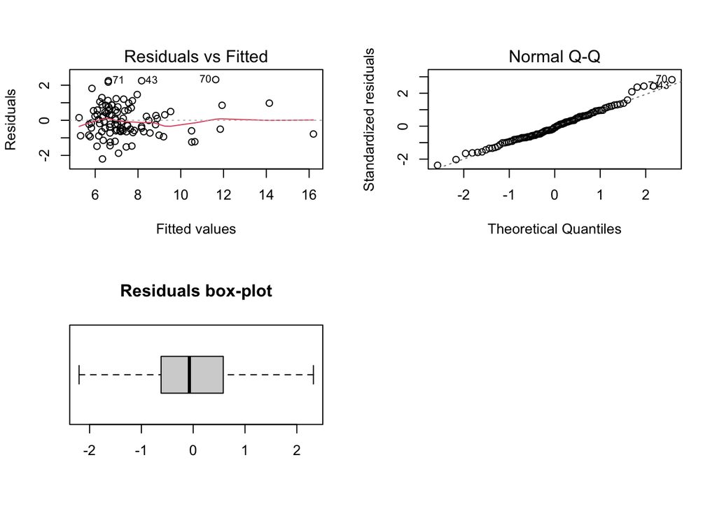

```r
par(mfrow=c(2,2))
plot(model2, which=1)
plot(model2, which=2)
boxplot(residuals(model2), horizontal=T, main='Residuals box-plot')
```

The model assumptions appear to hold better under Model 2 compared to under Model 1.

- The residuals vs fitted plot. There is no particular nonlinear pattern.
- The Normal QQ plot. Almost all points fall on a straight line (so, normality holds).
- The box-plot. No outliers are present.
- **(h). Under Model 2, obtain the 99% confidence interval for the mean response when $X1=X2=0$.**

```r
X1.bar = mean(data$X1)
X2.bar = mean(data$X2)
Xh = matrix(c(1, 0-X1.bar, 0-X2.bar, (0-X1.bar)^2, (0-X2.bar)^2, (0-X1.bar)*(0-X2.bar)), nrow=6, ncol=1)
X  = cbind(1, x1, x2, x1^2, x2^2, x1*x2)
```

Compute
$$s\{\hat{Y}_h\}=\sqrt{{\rm
MSE}[X_h'(X'X)^{-1}X_h]}$$

```r
mse = summary(model2)$sigma^2
s.Yh = sqrt( mse * (t(Xh) %*% solve(t(X) %*% X) %*% Xh) )
s.Yh
```

```
##           [,1]
## [1,] 0.7003479
```

Then construct the 99$\%$ confidence interval for $E(Y_h)$:
$$\hat{Y}_h\pm
t(1-\frac{\alpha}{2};\hspace{1mm}n-p)s\{\hat{Y}_h\}$$

```r
alpha = 1-0.99
y.hat = t(Xh) %*% coef(model2)
y.hat - qt(1-alpha/2, 94) * s.Yh # lower bound
```

```
##         [,1]
## [1,] 3.41719
```

```r
y.hat + qt(1-alpha/2, 94) * s.Yh # upper bound
```

```
##          [,1]
## [1,] 7.099826
```

Hence, the 99% confidence interval for the mean response when $X_1=X_2=0$ is:
$$(3.4171896,\quad 7.0998258).$$

- **(i). At the significance level 0.01, test whether or not all terms involving *X2* may be simultaneously dropped out of Model 2. State your conclusion.**

Recall Model 2:
$$Y_{i}=\beta_0+\beta_1\tilde{X}_{i1}+\beta_2\tilde{X}_{i2}+\beta_3\tilde{X}_{i1}^2+\beta_4\tilde{X}_{i2}^2+\beta_5\tilde{X}_{i1}\tilde{X}_{i2}+\varepsilon_i.$$

To test whether or not all terms involving $X_2$ may be simultaneously dropped out of Model 2, we have
$$H_0:\beta_2=\beta_4=\beta_5=0,\quad H_1:\text{at
least one of }\beta_2,\beta_4,\beta_5\text{ is not zero.}$$

```r
alpha = 0.01
reduced.model2 = lm(data$Y ~ x1 + I(x1^2))
anova(reduced.model2)
```

```
## Analysis of Variance Table
##
## Response: data$Y
##           Df  Sum Sq Mean Sq F value    Pr(>F)
## x1         1  90.879  90.879   74.77 1.112e-13 ***
## I(x1^2)    1 174.002 174.002  143.16 < 2.2e-16 ***
## Residuals 97 117.899   1.215
## ---
## Signif. codes:  0 '***' 0.001 '**' 0.01 '*' 0.05 '.' 0.1 ' ' 1
```

Reduced Model 2: SSE(R)=117.899 with $df_R$ = $n-3=97$.

```r
anova(model2)
```

```
## Analysis of Variance Table
##
## Response: data$Y
##           Df  Sum Sq Mean Sq  F value    Pr(>F)
## x1         1  90.879  90.879 103.4965 < 2.2e-16 ***
## x2         1  24.853  24.853  28.3040 7.005e-07 ***
## I(x1^2)    1 183.736 183.736 209.2445 < 2.2e-16 ***
## I(x2^2)    1   0.541   0.541   0.6162    0.4344
## x1:x2      1   0.230   0.230   0.2615    0.6103
## Residuals 94  82.541   0.878
## ---
## Signif. codes:  0 '***' 0.001 '**' 0.01 '*' 0.05 '.' 0.1 ' ' 1
```

Full Model 2: SSE(F)=82.541 with $df_F$ = $n-6=94$.

The test statistic
$$F^*=\frac{(SSE(R)-SSE(F))/3}{SSE(F)/94}=\frac{35.358/3}{82.541/94}=13.422.$$

```r
qf(1-alpha, 3, 94)
```

```
## [1] 3.997044
```

Since $F^*>F(1-\alpha;3,94)$, we reject $H_0$ and conclude that all terms involving $X_2$ may NOT be simultaneously dropped out of Model 2 at level $\alpha=0.01$.

- **(j) Find a model that has less regression coefficients AND a larger adjusted coefficient of multiple determination compared to Model 2. Briefly explain how you reach this model.**

We propose Model 3:
$$Y_i=\beta_0+\beta_1\tilde{X}_{i1}+\beta_2X_{i2}+\beta_3\tilde{X}_{i1}^2+\varepsilon_i,$$

which has less regression coefficients AND a larger adjusted coefficient of multiple determination $R^2_a$ compared to Model 2.

```r
model3 = lm(data$Y ~ x1 + data$X2 + I(x1^2))
summary(model3)
```

```
##
## Call:
## lm(formula = data$Y ~ x1 + data$X2 + I(x1^2))
##
## Residuals:
##      Min       1Q   Median       3Q      Max
## -2.22047 -0.56627 -0.08829  0.53604  2.53136
##
## Coefficients:
##             Estimate Std. Error t value Pr(>|t|)
## (Intercept)  4.69350    0.30774  15.252  < 2e-16 ***
## x1           0.82123    0.09907   8.290 6.89e-13 ***
## data$X2      0.59043    0.09352   6.313 8.46e-09 ***
## I(x1^2)      0.99374    0.06830  14.551  < 2e-16 ***
## ---
## Signif. codes:  0 '***' 0.001 '**' 0.01 '*' 0.05 '.' 0.1 ' ' 1
##
## Residual standard error: 0.9316 on 96 degrees of freedom
## Multiple R-squared:  0.7824, Adjusted R-squared:  0.7756
## F-statistic:   115 on 3 and 96 DF,  p-value: < 2.2e-16
```

As we can see, the $R^2_a$ of Model 3

```r
summary(model3)$adj.r.squared
```

```
## [1] 0.7755505
```

is slightly larger than the $R^2_a$ of Model 2

```r
summary(model2)$adj.r.squared
```

```
## [1] 0.7728955
```

We choose Model 3 like this because the terms $\tilde{X}_{2}^2$ and $\tilde{X}_{1}\tilde{X}_{2}$ are not important in explaining $Y$ when $\tilde{X}_{1}$, $\tilde{X}_{2}$, and $\tilde{X}_{1}^2$ are already included in the model. See the ANOVA table of Full Model 2 in part (i).